# Steel Fatigue Strength Prediction

## 1. Dataset and project description

### 1.1

**Introduction of Dataset:** This dataset is focused on predicting the fatigue strength of steel materials. It contains information about various steel samples and their properties, aimed at understanding and predicting their fatigue behavior. Fatigue behavior refers to how a material, in this case steel, responds to repeated cycles of stress or strain over time. Understanding fatigue behavior is crucial for predicting the lifespan and performance of materials.

**Source:** The dataset is hosted on Kaggle from National Institute for Materials Science (NIMS), Japan, provided by [https://link.springer.com/article/10.1186/2193-9772-3-8#additional-information]. It appears to be compiled from experimental data in materials science and engineering, specifically in the field of steel fatigue strength testing. link: https://www.kaggle.com/datasets/chaozhuang/steel-fatigue-strength-prediction

**Features:** There are total of 25 Features. Here is the list of features-

1. Chemical Composition (in weight percentage):

   C: Carbon Si: Silicon Mn: Manganese P: Phosphorus S: Sulphur Ni: Nickel Cr: Chromium Cu: Copper Mo: Molybdenum
2. Heat Treatment Parameters:

   NT: Normalizing Temperature THT: Through Hardening Temperature THt: Through Hardening Time THQCr: Cooling Rate for Through Hardening CT: Carburization Temperature Ct: Carburization Time DT: Diffusion Temperature Dt: Diffusion time QmT: Quenching Media Temperature (for Carburization) TT: Tempering Temperature Tt: Tempering Time TCr: Cooling Rate for Tempering
3. Processing Parameters:

   RedRatio: Reduction Ratio (Ingot to Bar)
4. Inclusion Parameters:

   dA: Area Proportion of Inclusions Deformed by Plastic Work dB: Area Proportion of Inclusions Occurring in Discontinuous Array dC: Area Proportion of Isolated Inclusions

**Challenges/ Limitations:**

1. Risk of Overfitting:

   With 27 dimensions and only 437 samples, the data space is sparsely populated. This can lead to unreliable distance measurements between data points, affecting the performance of distance-based algorithms.
3. Feature Selection/Dimensionality Reduction:

   Careful feature selection or dimensionality reduction techniques will be crucial to mitigate overfitting.Techniques like Principal component analysis (PCA)/ Recurssive Feature Elimination (RFE) might be necessary.

### 1.2

**About the target variable**

For the purpose of our predictive regression task, the target variable is Fatigue (Measured as rotating bending fatigue strength at 10^7 cycles). We will be predicting the fatigue strength of steel based on its chemical composition, heat treatment conditions, mechanical properties, and other processing parameters.

**Rationale**

In materials engineering, components that experience cyclic loading such as in automotive, aerospace, and structural application, fatigue strength is a critical property. Components with high fatigue strength are less likely to fail under repeated stress. This directly impacts the safety and longevity of structures. Understanding and predicting fatigue strength can highly influence material section and design processes. Moreover, ensuring accurate predictions of fatigue strength can make heat treatment processes and chemical compositions efficient, therefore reducing the need for extensive physical testing and saving immense time & resources.

**Relevant Features**

1. Chemical Composition:

   The chemical makeup of the steel plays an important role in determining its mechanical properties, including the fatigue strength. These include - %C, %Si, %Mn, %P, %S, %Ni, %Cr, %Cu, %Mo
2. Heat Treatment Conditions:

   The temperatures, times, and cooling rates for various heat treatment processes can affect the microstructure and mechanical properties of steel. Following are the feature columns - NT, THT, THt, THQCr, CT, Ct, DT, Dt, QmT, TT, Tt, TCr
3. Processing details:

   The dataset includes various details about the reduction ratio and characterisitics of non-metallic inclusions that can impact fatigue strength. These inclusions often act as crack initiation points. Features (RedRatio, dA, dB, dC)

**Potential challenges**

1. Domain Knowledge Integration: Effectively incorporating metallurgical knowledge into the model development process to ensure physical plausibility of predictions.
2. Handling Outliers: Extreme values in composition or processing parameters might represent either rare alloys or potential data errors, requiring careful consideration.
3. Generalizability: The model's ability to generalize to steel compositions or processing conditions not well-represented in the dataset may be limited.

**Relevance and Interest**

If we are successful in predicting accurate fatigue strength, it can revolutionize how materials are designed and processed in industries that dependent heavily on high-performance materials. We can leverage predictive modeling so that manufacturers can optimize steel chemical composition, heat conditions, and processing parameters to achieve desired fatigue properties. This interesting analysis will allow us to solve the problem of building structures with weak materials. Ultimately, we can reduce material testing costs, enhance the safety, and improve the performance of engineering components.

## 2. Data Preprocessing

```python
# Importing required packages

import pandas as pd
import numpy as np
import matplotlib.pyplot as plt

from sklearn.feature_selection import f_regression, mutual_info_regression
from sklearn.model_selection import train_test_split
from sklearn.ensemble import IsolationForest
from sklearn.preprocessing import StandardScaler
from sklearn.decomposition import PCA
from sklearn.model_selection import KFold
from sklearn.model_selection import GridSearchCV
from sklearn.linear_model import LinearRegression

from sklearn.svm import SVR
from sklearn.ensemble import GradientBoostingRegressor, RandomForestRegressor
from sklearn.neighbors import KNeighborsRegressor
from sklearn.linear_model import ElasticNet
from sklearn.metrics import mean_absolute_error, r2_score
```

```python
# Importing the dataset
df = pd.read_csv('data.csv')
df.info()
```

```
<class 'pandas.core.frame.DataFrame'>
RangeIndex: 437 entries, 0 to 436
Data columns (total 27 columns):
 #   Column    Non-Null Count  Dtype
---  ------    --------------  -----
 0   Sl. No.   437 non-null    int64
 1   NT        437 non-null    int64
 2   THT       437 non-null    int64
 3   THt       437 non-null    int64
 4   THQCr     437 non-null    int64
 5   CT        437 non-null    int64
 6   Ct        437 non-null    float64
 7   DT        437 non-null    float64
 8   Dt        437 non-null    float64
 9   QmT       437 non-null    int64
```

[output cut: 19 more lines]

```python
# Setting Sl. No. as index
df.set_index('Sl. No.', inplace=True)
df.head()
```

| Sl. No. | NT | THT | THt | THQCr | CT | Ct | DT | Dt | QmT | TT | ... | S | Ni | Cr | Cu | Mo | RedRatio | dA | dB | dC | Fatigue |
| --- | --- | --- | --- | --- | --- | --- | --- | --- | --- | --- | --- | --- | --- | --- | --- | --- | --- | --- | --- | --- | --- |
| 1 | 885 | 30 | 0 | 0 | 30 | 0.0 | 30.0 | 0.0 | 30 | 30 | ... | 0.022 | 0.01 | 0.02 | 0.01 | 0.0 | 825 | 0.07 | 0.02 | 0.04 | 232 |
| 2 | 885 | 30 | 0 | 0 | 30 | 0.0 | 30.0 | 0.0 | 30 | 30 | ... | 0.017 | 0.08 | 0.12 | 0.08 | 0.0 | 610 | 0.11 | 0.00 | 0.04 | 235 |
| 3 | 885 | 30 | 0 | 0 | 30 | 0.0 | 30.0 | 0.0 | 30 | 30 | ... | 0.015 | 0.02 | 0.03 | 0.01 | 0.0 | 1270 | 0.07 | 0.02 | 0.00 | 235 |
| 4 | 885 | 30 | 0 | 0 | 30 | 0.0 | 30.0 | 0.0 | 30 | 30 | ... | 0.024 | 0.01 | 0.02 | 0.01 | 0.0 | 1740 | 0.06 | 0.00 | 0.00 | 241 |
| 5 | 885 | 30 | 0 | 0 | 30 | 0.0 | 30.0 | 0.0 | 30 | 30 | ... | 0.022 | 0.01 | 0.02 | 0.02 | 0.0 | 825 | 0.04 | 0.02 | 0.00 | 225 |

5 rows × 26 columns

```python
# Splitting the dataset into features and target variables

# features
X = df.drop('Fatigue',axis=1)

# target
Y = df['Fatigue']
```

### 2.1 Train-test split

```python
# Splitting dataset into X,Y Train test values
X_train, X_test, Y_train, Y_test = train_test_split(X, Y, test_size=0.20)
```

### 2.2 Preprocessing steps

#### Handling missing data

```python
# Check for NaN values in features (X)
print("Missing values in features (X):", np.isnan(X).sum())

# Check for NaN values in target (Y)
print("Missing values in target (Y):", np.isnan(Y).sum())
```

```
Missing values in features (X): NT          0
THT         0
THt         0
THQCr       0
CT          0
Ct          0
DT          0
Dt          0
QmT         0
TT          0
Tt          0
TCr         0
C           0
Si          0
Mn          0
P           0
S           0
Ni          0
Cr          0
Cu          0
Mo          0
RedRatio    0
dA          0
dB          0
dC          0
dtype: int64
Missing values in target (Y): 0
```

This shows that our dataset does not include any null values. Hence, no null values need to be dropped.

#### Outlier detection and removal

We are using Isolation Forest algorithm for outlier detection because it effectively identifies anomalies by isolating observations in a random sub-sample of data. Given the complexity of the dataset, this method is particularly suitable as it can handle high-dimensional data efficiently and is robust to irrelevant features.

```python
# Setting the contamination
outliers_fraction = 0.11

# create an instance
model =  IsolationForest(n_estimators=500, max_samples = 0.8, max_features= 0.8, contamination = outliers_fraction,bootstrap=True)

# train isolation forest model
model.fit(X_train)

# predict train outliers
outlier_labels = model.predict(X_train)

# Inlier training dataset
X_train_i = X_train[outlier_labels==1] ## inlier training feature set
Y_train_i = Y_train[outlier_labels==1] ## inlier training target set

# Inlier test dataset
X_test_i =X_test[model.predict(X_test)==1] ## inlier test feature set
Y_test_i =Y_test[model.predict(X_test)==1] ## inlier test target set

# Number of outliers detected and removed
print('Number of outliers removed:',len(X_train[outlier_labels==-1])) # outlier in training data
```

```
Number of outliers removed: 39
```

#### Scaling

We are using the StandardScaler to standardize our dataset. Standardization helps ensure that each feature contributes equally to the analysis, improving the performance of subsequent models, especially those sensitive to feature scaling.

```python
# instantiate
scaler = StandardScaler()

# Training the model
scaler.fit(X_train_i)

# transform the train dataset to standardized data
X_train_s_i = scaler.transform(X_train_i)

# standardized training dataset
print("standard deviation for X_train_s_i: \n%s " % X_train_s_i.std(axis=0))

# transform the test data to standardized data
X_test_s_i  = scaler.transform(X_test_i)

# standardized test dataset
print("\nstandard deviation for X_test_s_ii: \n%s " % X_test_s_i.std(axis=0))
```

```
standard deviation for X_train_s_i:
[1. 1. 1. 1. 1. 1. 1. 1. 1. 1. 1. 1. 1. 1. 1. 1. 1. 1. 1. 1. 1. 1. 1. 1.
 1.]

standard deviation for X_test_s_ii:
[1.02229956 1.13085777 1.13154855 0.99190182 1.13154855 1.03673813
 1.13624641 1.09447179 0.72984665 1.0521418  1.13154855 1.13154855
 1.02562317 0.50424144 1.05710305 0.91779459 0.93971201 1.01704172
 0.97101797 1.07480628 1.05493974 0.66756562 0.94665517 1.09874803
 1.25993649]
```

#### Feature selection

We have used ANOVA F-statistic scores and Mutual Information (MI) scores for feature selection to understand the association between features and the target variable. A large F-score with a small p-value indicates a strong linear relationship and statistical significance, suggesting that the feature is likely important for prediction. A large MI score complements this by capturing the non-linear dependencies. This combination helps ensure that selected features are both statistically significant and informative.

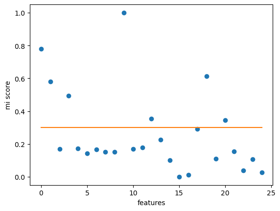

```python
# Calculating f score and p value
f, p = f_regression(X_train_s_i, Y_train_i)
f /= np.max(f) # normalize f score

# Calculating mi score
mi = mutual_info_regression(X_train_s_i, Y_train_i)
mi /= np.max(mi) # normalize mi score


## find the threshold for mi score
plt.figure()
plt.plot(mi, 'o')
plt.plot(0.3*np.ones(len(mi)))
plt.ylabel('mi score')
plt.xlabel('features')
```

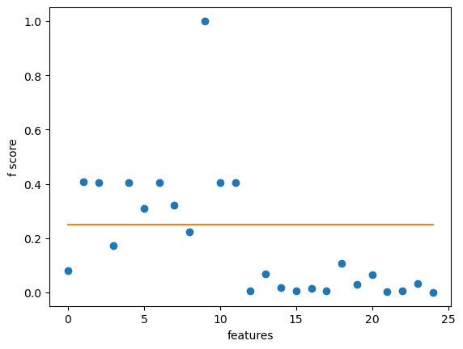

```python
## find the threshold for f score
plt.figure()
plt.plot(f, 'o')
plt.plot(0.25*np.ones(len(f)))
plt.ylabel('f score')
plt.xlabel('features')
```

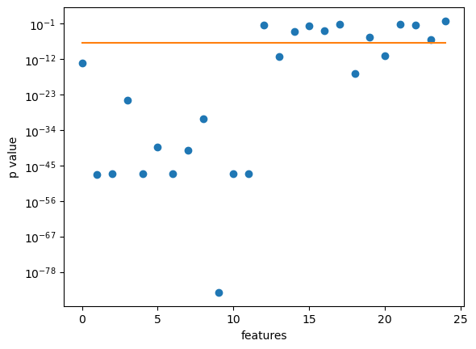

```python
## Finding threshold for p values
plt.figure()
plt.semilogy(p, 'o')
plt.plot(10**-7*np.ones(len(f)))
plt.ylabel('p value')
plt.xlabel('features')
```

```python
# Feature Selection using mask (f>0.25) or MI values (mi>0.3)]
X_train_s_i_r = X_train_s_i[:,(f > 0.25) | (mi > 0.3)]
X_test_s_i_r = X_test_s_i[:,(f > 0.25) | (mi > 0.3)]

print(X_train_s_i_r.shape)
print(X_test_s_i_r.shape)
```

```
(310, 14)
(80, 14)
```

#### Feature Reduction

We are using Principal Component Analysis (PCA) to reduce the features in our dataset while retaining 95% of the variance. This method is particularly beneficial because it helps eliminate redundant and collinear features, simplifying the model without losing critical information. By focusing on the most significant components, we can improve the model performance.

```python
# Instantiate PCA and explaining 95% variance in the dataset
pca = PCA(n_components=0.95)

# Fitting PCA on the standardized inlier training data and transforming it
X_train_pca = pca.fit_transform(X_train_s_i_r)

# Transform the standardized inlier test data
X_test_pca = pca.transform(X_test_s_i_r)

# Displaying shape for train and test datasets
print(X_train_pca.shape)
print(X_test_pca.shape)
```

```
(310, 5)
(80, 5)
```

### 2.3 Preprocessing sequence

The preprocessing steps we have chosen are as follows-

1. Outlier Detection using Isolation Forest **-->** 2. Scaling using Standard Scaler **-->** 3. Feature Selection using ANOVA F-statistic scores and Mutual Information (MI) scores **-->** 4. Feature Reduction using PCA

We believe this is the best set of sequence because -

By detecting and removing outliers before scaling, we prevent extreme values from skewing the scaling process, which could disproportionately affect the mean and standard deviation. Scaling is necessary before PCA, as PCA is sensitive to feature scaling. Features with larger magnitudes would dominate the principal components if left unscaled. Implementing feature selection next allows us to retain only the most relevant features based on their relationship with the target variable, which streamlines the dataset for more efficient processing. Feature reduction through PCA is done last, as it helps us reduce dimensionality while retaining the most important variations in the dataset only after the dataset has been cleaned and normalized. These steps should increase the likelihood of enhancing our models' generalization performance.

We also tried the following Sequence- Scaling → Outlier Detection → PCA

However, we received poor PCA results. This was mainly due to the fact that we did Scaling before removing outliers which distorted the mean and the standard deviation for the dataset, leading to incorrect detection of anomalies and poor PCA results. This sequence doesn't adequately clean or standardize the data, resulting in a less robust dataset for model training.

Hence, we believe the steps we have chosen lead to an optimal solution.

## 3. Model Training and Testing

### 3.1 Hyperparameter Optimization

We have selected the following 5 regression techniques -

1. Gradient Boosting
2. Random Forest
3. Support Vector Regression (SVR)
4. Linear Regression
5. K Nearest Neighbors (KNN)

```python
# Setting up parameters

# Support Vector Regression
svr = SVR()
svr_param = {'C': [0.1, 1, 10, 100], 'epsilon': [0.01, 0.1, 0.5]}

# Gradient Boosting Regressor
gbr = GradientBoostingRegressor()
gbr_param = {'n_estimators': [100, 200, 300], 'learning_rate': [0.01, 0.1, 0.2], 'max_depth': [3, 5, 7, 10, 20]}

# K-Nearest Neighbors Regressor
knn = KNeighborsRegressor()
knn_param = {'n_neighbors': [3, 5, 7, 10]}

# Linear Regression
lr = LinearRegression()
lr_param = {}

# Random Forest Regressor
rf = RandomForestRegressor()
rf_param = {'n_estimators': [100, 200, 300], 'max_depth': [3, 5, 7, 10, 20]}
```

```python
# Prepare Grid Searches
grid_svr = GridSearchCV(svr, param_grid=svr_param, cv=5, verbose=1)
grid_gb = GridSearchCV(gbr, param_grid=gbr_param, cv=5, verbose=1)
grid_knn = GridSearchCV(knn, param_grid=knn_param, cv=5, verbose=1)
grid_lr = GridSearchCV(lr, param_grid=lr_param, cv=5, verbose=1)
grid_rf = GridSearchCV(rf, param_grid=rf_param, cv=5, verbose=1)
```

```python
# Defining results
results = {}

# SVR
grid_svr.fit(X_train_pca, Y_train_i)
results['SVR'] = (grid_svr.best_params_, grid_svr.best_score_)

# Gradient Boosting
grid_gb.fit(X_train_pca, Y_train_i)
results['Gradient Boosting'] = (grid_gb.best_params_, grid_gb.best_score_)

# KNN
grid_knn.fit(X_train_pca, Y_train_i)
results['KNN'] = (grid_knn.best_params_, grid_knn.best_score_)

# Linear Regression
grid_lr.fit(X_train_pca, Y_train_i)
results['Linear Regression'] = (grid_lr.best_params_, grid_lr.best_score_)

# Random Forest
grid_rf.fit(X_train_pca, Y_train_i)
results['Random Forest'] = (grid_rf.best_params_, grid_rf.best_score_)

# Print results
for model, (params, score) in results.items():
    print(f"{model}: Best Params: {params}, Best Score: {score}")
```

```
Fitting 5 folds for each of 12 candidates, totalling 60 fits
Fitting 5 folds for each of 45 candidates, totalling 225 fits
Fitting 5 folds for each of 4 candidates, totalling 20 fits
Fitting 5 folds for each of 1 candidates, totalling 5 fits
Fitting 5 folds for each of 15 candidates, totalling 75 fits
SVR: Best Params: {'C': 100, 'epsilon': 0.1}, Best Score: 0.9406426897765623
Gradient Boosting: Best Params: {'learning_rate': 0.1, 'max_depth': 3, 'n_estimators': 100}, Best Score: 0.9433921837026791
KNN: Best Params: {'n_neighbors': 7}, Best Score: 0.9408251318203498
Linear Regression: Best Params: {}, Best Score: 0.9080026093462269
Random Forest: Best Params: {'max_depth': 10, 'n_estimators': 300}, Best Score: 0.9438889223729406
```

### 3.2 Comparing Generalization vs Memorization

Metric chosen to compare - **Mean Absolute Value**

```python
# Generalization using MAE

# Define dictionary to store generalization results
mae_results_generalization = {}

# Function to calculate MAE
def mae_score(model_name, X, Y):
    Y_pred = model_name.predict(X)
    mae = mean_absolute_error(Y, Y_pred)
    return mae

# Calculate MAE for each optimized model (generalization)
mae_results_generalization['SVR'] = mae_score(grid_svr.best_estimator_, X_test_pca, Y_test_i)
mae_results_generalization['Gradient Boosting'] = mae_score(grid_gb.best_estimator_, X_test_pca, Y_test_i)
mae_results_generalization['KNN'] = mae_score(grid_knn.best_estimator_, X_test_pca, Y_test_i)
mae_results_generalization['Linear Regression'] = mae_score(grid_lr.best_estimator_, X_test_pca, Y_test_i)
mae_results_generalization['Random Forest'] = mae_score(grid_rf.best_estimator_, X_test_pca, Y_test_i)

# Extract model names and MAE values
model_names = list(mae_results_generalization.keys())
mae_scores_generalization = list(mae_results_generalization.values())
```

```python
# Memorization using MAE

# Define dictionary to store memorization results
mae_results_memorization = {}

# Calculate MAE for each optimized model (memorization)
mae_results_memorization['SVR'] = mae_score(grid_svr.best_estimator_, X_train_pca, Y_train_i)
mae_results_memorization['Gradient Boosting'] = mae_score(grid_gb.best_estimator_, X_train_pca, Y_train_i)
mae_results_memorization['KNN'] = mae_score(grid_knn.best_estimator_, X_train_pca, Y_train_i)
mae_results_memorization['Linear Regression'] = mae_score(grid_lr.best_estimator_, X_train_pca, Y_train_i)
mae_results_memorization['Random Forest'] = mae_score(grid_rf.best_estimator_, X_train_pca, Y_train_i)

# Extract MAE values
mae_scores_memorization = list(mae_results_memorization.values())
```

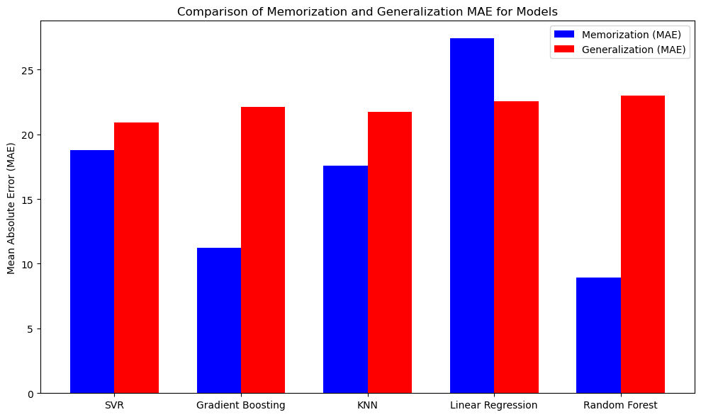

```python
# Set the positions and width for the bars
x = np.arange(len(model_names))
width = 0.35

# Create a bar plot
fig, ax = plt.subplots(figsize=(10, 6))
bars1 = ax.bar(x - width/2, mae_scores_memorization, width, label='Memorization (MAE)', color='blue')
bars2 = ax.bar(x + width/2, mae_scores_generalization, width, label='Generalization (MAE)', color='red')

# Add plot properties and labels
ax.set_ylabel('Mean Absolute Error (MAE)')
ax.set_title('Comparison of Memorization and Generalization MAE for Models')
ax.set_xticks(x)
ax.set_xticklabels(model_names)
ax.legend()

# Show plot
plt.tight_layout()
plt.show()
```

In the plot, the blue bars represent the Memorization (training) Mean Absolute Error (MAE), while the red bars represent the Generalization (testing) MAE across different regression models.

Given that Gradient Boosting and Random Forest have lower Memorization MAE but have a larger gap between Memorization and Generalization MAE compared to SVR and KNN, we decided to focus on which models balance both memorization and generalization effectively.

**Most Reliable Techniques**: KNN & SVR

**Explanation:**

- KNN and SVR have a smaller gap between Memorization and Generalization MAE, indicating they are less prone to overfitting and generalize better to unseen data.
- KNN and SVR have a high cross validation score (~94%)
- Even though Gradient Boosting and Random Forest have lower Memorization MAE, their significant gap suggests that they may not generalize as effectively, potentially overfitting the training data.

Therefore, KNN and SVR are more reliable for predictive tasks in this context since they offer a more balanced performance between training and testing error.

## 4. Additional Analysis

### 4.1 Impact of Training dataset on Generalization Performance

For this question, we will analyze the generalization performance of **KNN** and **SVR** models by analyzing their Mean Absolute Error (MAE) and R² scores against the training dataset sizes

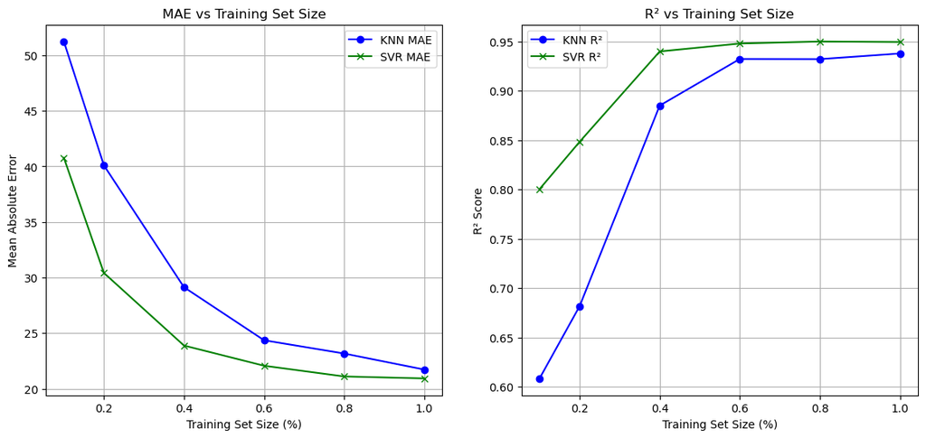

```python
# Training set sizes
training_sizes = [0.1, 0.2, 0.4, 0.6, 0.8, 1.0]

# Creating arrray for storing performance results
mae_scores_knn = []
mae_scores_svr = []
r2_scores_knn = []
r2_scores_svr = []

# Function to calculate MAE and R2 score
def mae_r2_score(model_name, X, Y):
    Y_pred = model_name.predict(X)
    mae = mean_absolute_error(Y, Y_pred)
    r2 = r2_score(Y, Y_pred)
    return mae,r2


# Iterating through increasing training sets
for i in training_sizes:

    # Subset the training data
    X_train_pca_subset = X_train_pca[:int(len(X_train_pca) * i)]
    Y_train_i_subset = Y_train_i[:int(len(Y_train_i) * i)]

    # Train KNN model (optimized) on the subset
    knn_optimized = KNeighborsRegressor(n_neighbors=7)
    knn_optimized.fit(X_train_pca_subset, Y_train_i_subset)

    # Train SVR (optimized) on the subset
    svr_optimized = SVR(C=100, epsilon=0.1)
    svr_optimized.fit(X_train_pca_subset, Y_train_i_subset)

    # Calculate MAE and R2 scores for KNN model
    mae_knn,r2_knn = mae_r2_score(knn_optimized, X_test_pca, Y_test_i) #X_test_pca, #Y_test_i test size remains same
    mae_scores_knn.append(mae_knn)
    r2_scores_knn.append(r2_knn)

    # Calculate MAE and R2 for SVR Model
    mae_svr, r2_svr = mae_r2_score(svr_optimized, X_test_pca, Y_test_i) #X_test_pca, #Y_test_i test size remains same
    mae_scores_svr.append(mae_svr)
    r2_scores_svr.append(r2_svr)

# Plotting the results
plt.figure(figsize=(14, 6))

# MAE plot
plt.subplot(1, 2, 1)
plt.plot(training_sizes, mae_scores_knn, marker='o', label='KNN MAE', color='blue')
plt.plot(training_sizes, mae_scores_svr, marker='x', label='SVR MAE', color='green')
plt.xlabel('Training Set Size (%)')
plt.ylabel('Mean Absolute Error')
plt.title('MAE vs Training Set Size')
plt.legend()
plt.grid(True)

# R² Score plot
plt.subplot(1, 2, 2)
plt.plot(training_sizes, r2_scores_knn, marker='o', label='KNN R²', color='blue')
plt.plot(training_sizes, r2_scores_svr, marker='x', label='SVR R²', color='green')
plt.xlabel('Training Set Size (%)')
plt.ylabel('R² Score')
plt.title('R² vs Training Set Size')
plt.legend()
plt.grid(True)
```

Based on the observations gathered by analyzing the impact of increasing training dataset size on generalization performance, it is evident that both K-Nearest Neighbors (KNN) and Support Vector Regression (SVR) show improved performance as the size of the training dataset increases. Specifically, the Mean Absolute Error (MAE) decreases and the R² score increases with larger training sets, indicating that both models are becoming more effective at capturing the underlying patterns in the data.

However, after a certain point, the benefits of increasing the training dataset size diminish. As the training set approaches the full dataset, both models tend to stabilize in performance, indicating that additional data may contribute less to improving the model's generalization ability.

Thus, while more training data can initially enhance model performance, but beyond a specific threshold the incremental gains in the model's performance become marginal.

Moreover, the SVR model outperforms the KNN model as it achievs a higher R² score and lower MAE value as the training dataset size increases. This indicates that SVR model captures the underlying patterns in the data more effectively and hence, leads to better generalization performance.

### 4.2 Best sequence of feature preprocessing

**NOTE** -

1. Outlier detection was not included in the preprocessing sequence because it involves removing or modifying data points. This would alter the dataset and make it challenging to maintain a consistent test dataset across all evaluations and ensure a fair comparison of model performance.
2. We applied scaling before PCA in every sequence since PCA requires the data to be standardized for optimal performance.

```python
# Defining dictionary to store results
results_preprocessing_knn = {}
results_preprocessing_svr = {}

#SEQUENCE 1: Scaling --> Feature Selection --> PCA

# Step 1: Scaling
scaler = StandardScaler()
scaler.fit(X_train_i)
X_train_1 = scaler.transform(X_train_i)
X_test_1 = scaler.transform(X_test_i)

# Step 2: Feature Selection using f-score and mutual information
f, p = f_regression(X_train_1, Y_train_i)
f /= np.max(f)
mi = mutual_info_regression(X_train_1, Y_train_i)
mi /= np.max(mi)
X_train_2 = X_train_1[:, (f > 0.25) | (mi > 0.3)]
X_test_2 = X_test_1[:, (f > 0.25) | (mi > 0.3)]

# Step 3: Dimensionality Reduction using PCA
pca = PCA(n_components=0.95)
X_train_preprocessed = pca.fit_transform(X_train_2)
X_test_preprocessed = pca.transform(X_test_2)

# Training KNN model
knn_optimized = KNeighborsRegressor(n_neighbors=7)
knn_optimized.fit(X_train_preprocessed, Y_train_i)

# Training SVR model
svr_optimized = SVR(C=100, epsilon=0.1)
svr_optimized.fit(X_train_preprocessed, Y_train_i)

# Evaluating mae and r2 scores
mae_knn, r2_knn = mae_r2_score(knn_optimized, X_test_preprocessed, Y_test_i)
mae_svr, r2_svr = mae_r2_score(svr_optimized, X_test_preprocessed, Y_test_i)

# Store results
results_preprocessing_knn['[Scaling, Feature Selection, PCA]'] = {'MAE': mae_knn, 'R²': r2_knn}
results_preprocessing_svr['[Scaling, Feature Selection, PCA]'] = {'MAE': mae_svr, 'R²': r2_svr}
```

```python
#SEQUENCE 2: Feature Selection--> Scaling --> PCA

# Step 1: Feature Selection using f-score and mutual information
f, p = f_regression(X_train_i, Y_train_i)
f /= np.max(f)
mi = mutual_info_regression(X_train_i, Y_train_i)
mi /= np.max(mi)
mask = (f > 0.25) | (mi > 0.3)
X_train_1 = X_train_i.loc[:, mask]
X_test_1 = X_test_i.loc[:, mask]


# Step 2: Scaling
scaler = StandardScaler()
scaler.fit(X_train_1)
X_train_2 = scaler.transform(X_train_1)
X_test_2 = scaler.transform(X_test_1)

# Step 3: Dimensionality Reduction using PCA
pca = PCA(n_components=0.95)
X_train_preprocessed = pca.fit_transform(X_train_2)
X_test_preprocessed = pca.transform(X_test_2)

# Training KNN model
knn_optimized = KNeighborsRegressor(n_neighbors=7)
knn_optimized.fit(X_train_preprocessed, Y_train_i)

# Training SVR model
svr_optimized = SVR(C=100, epsilon=0.1)
svr_optimized.fit(X_train_preprocessed, Y_train_i)

# Evaluating mae and r2 scores
mae_knn, r2_knn = mae_r2_score(knn_optimized, X_test_preprocessed, Y_test_i)
mae_svr, r2_svr = mae_r2_score(svr_optimized, X_test_preprocessed, Y_test_i)

# Store results
results_preprocessing_knn['[Feature Selection, Scaling, PCA]'] = {'MAE': mae_knn, 'R²': r2_knn}
results_preprocessing_svr['[Feature Selection, Scaling, PCA]'] = {'MAE': mae_svr, 'R²': r2_svr}
```

```python
#SEQUENCE 3: Scaling --> PCA --> Feature Selection

# Step 1: Scaling
scaler = StandardScaler()
scaler.fit(X_train_i)
X_train_1 = scaler.transform(X_train_i)
X_test_1 = scaler.transform(X_test_i)

# Step 2: Dimensionality Reduction using PCA
pca = PCA(n_components=0.95)
X_train_2 = pca.fit_transform(X_train_1)
X_test_2 = pca.transform(X_test_1)

# Step 3: Feature Selection using f-score and mutual information
f, p = f_regression(X_train_2, Y_train_i)
f /= np.max(f)
mi = mutual_info_regression(X_train_2, Y_train_i)
mi /= np.max(mi)
X_train_preprocessed = X_train_2[:, (f > 0.25) | (mi > 0.3)]
X_test_preprocessed = X_test_2[:, (f > 0.25) | (mi > 0.3)]

# Training KNN model
knn_optimized = KNeighborsRegressor(n_neighbors=7)
knn_optimized.fit(X_train_preprocessed, Y_train_i)

# Training SVR model
svr_optimized = SVR(C=100, epsilon=0.1)
svr_optimized.fit(X_train_preprocessed, Y_train_i)

# Evaluating mae and r2 scores
mae_knn, r2_knn = mae_r2_score(knn_optimized, X_test_preprocessed, Y_test_i)
mae_svr, r2_svr = mae_r2_score(svr_optimized, X_test_preprocessed, Y_test_i)

# Store results
results_preprocessing_knn['[Scaling, PCA, Feature Selection]'] = {'MAE': mae_knn, 'R²': r2_knn}
results_preprocessing_svr['[Scaling, PCA, Feature Selection]'] = {'MAE': mae_svr, 'R²': r2_svr}
```

```python
# Displaying the results
print('Preprocessing results for KNN Model\n')
for key, value in results_preprocessing_knn.items():
    print(f"{key} -> MAE: {value['MAE']}, R²: {value['R²']}")

print('\nPreprocessing results for SVR Model\n')
for key, value in results_preprocessing_svr.items():
    print(f"{key} -> MAE: {value['MAE']}, R²: {value['R²']}")
```

```
Preprocessing results for KNN Model

[Scaling, Feature Selection, PCA] -> MAE: 21.466071428571425, R²: 0.9403008906601656
[Feature Selection, Scaling, PCA] -> MAE: 21.723214285714278, R²: 0.9380214274261869
[Scaling, PCA, Feature Selection] -> MAE: 40.392857142857146, R²: 0.8152132182013073

Preprocessing results for SVR Model

[Scaling, Feature Selection, PCA] -> MAE: 18.947237570607616, R²: 0.9563082907178568
[Feature Selection, Scaling, PCA] -> MAE: 20.925356484013356, R²: 0.9496515682983365
[Scaling, PCA, Feature Selection] -> MAE: 34.449291692509235, R²: 0.8719084320419106
```

**Explaination**

The sequence of preprocessing techniques significantly impacts the generalization performance for both the KNN and SVR models.

For both models, applying the sequence **[Scaling, Feature Selection, PCA]** resulted in the lowest MAE and the highest R² score, hence yielding the best performance. This suggests that scaling before feature selection helps to standardize the data and allows feature selection to identify the most relevant features more effectively. Performing PCA after these steps further reduces dimensionality and preserves the most critical information for the model’s predictive task.

In contrast, the sequence **[Scaling, PCA, Feature Selection]** performed the worst for both models as it gave a much higher MAE and lower R² score. This suggests that applying PCA before feature selection may discard valuable features that would otherwise improve model accuracy.

We can conlude that the order in which preprocessing steps are applied can have a substantial effect on model performance. Hence, we used the most optimal sequence for this project i.e., [Scaling, Feature Selection, PCA].